# Tarea 1

Estadística Actuarial II

José Ignacio Rojas Zárate, C16911

Montserrat Beirute Abarca, C10997

Valeria Vásquez Venegas, C18373

12 de enero de 2024

# Introducción

El presente documento prestan el código y resultados a los ejercicios de la Tarea 1 del curso. Para su realización, se utilizó el programa R studio.

El presente trabajo utilizó la base de datos “BaseSalarios” brindada por el profesor Esteban Bermúdez Aguilar.

La base de datos tiene 5 columnas. A continuación, se presentan los primeros seis registros de la base de datos “BaseSalarios” para poder explicar la información de cada columna.

Primeros 6 registros de la base de datos

| ID | Fec.Nac | Sexo | Coutas | Ultimo.Salario |
| --- | --- | --- | --- | --- |
| 1 | 1945-01-30 | 1 | 323 | 2 784 093.18 |
| 2 | 1949-06-17 | 2 | 342 | 532 324.93 |
| 3 | 1951-04-19 | 2 | 13 | 225 517.69 |
| 4 | 1950-02-05 | 2 | 323 | 1 612 733.09 |
| 5 | 1952-02-06 | 2 | 185 | 1 411 502.30 |
| 6 | 1954-01-10 | 2 | 284 | 1 915 751.19 |

La columna **ID** cuenta el número de registros disponibles, en este caso, se dispone de 106,002 registros. En la columna **Fec.Nac** se encuentra la información de la fecha de nacimiento de cada persona. En la tercera columna, **Sexo**, se observan los números 1 y 2; específicamente, si el valor de Sexo es 1, corresponde a hombres, y si es 2, corresponde a mujeres. La cuarta columna, **Cuotas** indica la cantidad de cuotas que cada persona ha aportado a un fondo de pensiones. Finalmente, la columna **Ultimo.Salario** contiene el último salario reportado, expresado en colones.

# Parte I

## Análisis descriptivo de las variables Cuotas y Salarios con respecto a la variable Sexo

Es de interés conocer las diferencias o similitudes en los datos del número de cuotas y los salarios según el sexo.

A continuación, se presenta un cuadro con un resumen estadístico de los datos del número de cuotas para hombres y mujeres.

Resumen estadístico de número de coutas por sexo

| Estadistico | Hombres | Mujeres |
| --- | --- | --- |
| Mínimo | 1.00 | 1.00 |
| Primer cuartil (Q1) | 61.00 | 66.00 |
| Mediana | 124.00 | 135.00 |
| Promedio | 135.18 | 142.97 |
| Tercer cuartil (Q3) | 198.00 | 213.00 |
| Máximo | 371.00 | 373.00 |
| Varianza | 7658.28 | 8187.47 |

Como se puede observar, tanto para mujeres como para hombres, el mínimo de cuotas aportadas es tan solo una.

Por su parte, se puede decir que en general las mujeres de la base de datos aportaron más cuotas que los hombres.

Se puede notar que el 25% de los hombres aportó 61 cuotas o menos, mientras que en el caso de las mujeres, el 25% aportó 66 cuotas o menos.

Además, el 50% de las mujeres aportó más de 135 cuotas, mientras que en el caso de los hombres, fue de 124 cuotas.

El promedio de cuotas es más alto para las mujeres (142.97) que para los hombres (135.18).

También, el 75% de las mujeres aportó 213 cuotas o menos, mientras que en el caso de los hombres, fue de 198 cuotas.

El valor máximo de cuotas aportadas para las mujeres fue de 373, mientras que para los hombres fue de 371.

Es importante resaltar que para ambos sexos, la varianza indica que los datos están alejados de la media y se presenta mucha variabilidad en los datos de número de cuotas aportadas al fondo de pensiones.

Por otra parte, a continuación, se presenta un cuadro con un resumen estadístico de los datos del último salario reportado para hombres y mujeres.

Resumen de Último Salario reportado por sexo

| Estadistico | Hombres | Mujeres |
| --- | --- | --- |
| Mínimo | 10 880.92 | 10 223.99 |
| Primer cuartil (Q1) | 552 498.30 | 584 757.36 |
| Mediana | 1 105 231.38 | 1 062 461.32 |
| Promedio | 1 157 201.59 | 1 046 661.46 |
| Tercer cuartil (Q3) | 1 611 785.71 | 1 403 025.79 |
| Máximo | 13 199 891.69 | 7 290 150.00 |
| Varianza | 509 080 243 512.55 | 287 419 606 660.60 |

En el Cuadro 3, se observa que el salario más bajo reportado le pertenece a una mujer, siendo tan solo 656.93 colones menos que el salario más bajo de los hombres.

En cuanto al Q1, se destaca que el 25% de los hombres tuvieron un último salario reportado de 552,498 colones o menos, mientras que el 25% de las mujeres tuvieron un último salario de 584,757 colones o menos. Es decir, en los últimos salarios más bajos, las mujeres experimentaron ingresos superiores a los de los hombres.

Además, el promedio de los últimos salarios fue mayor para los hombres, aproximadamente 110,540 colones más alto.

Las diferencias se incrementan a medida que se consideran los últimos salarios más altos. El 75% de las mujeres ganaron 1 403 025.79 o menos, mientras que el 75% de los hombres ganaron 1 611 786 colones o menos.

El salario máximo reportado por hombres es 5 909 742 colones más alto que el de las mujeres.

Es importante resaltar que la varianza para ambos sexos señala que los datos están muy dispersos de la media, es decir hay una gran variabilidad en los datos de último salario reportado.

## Gráfico plotbox para el salario para comparar entre las categorías de Sexo

El siguiente gráfico plotbox permite tener una representación visual de como se distribuyen los datos para cada sexo.

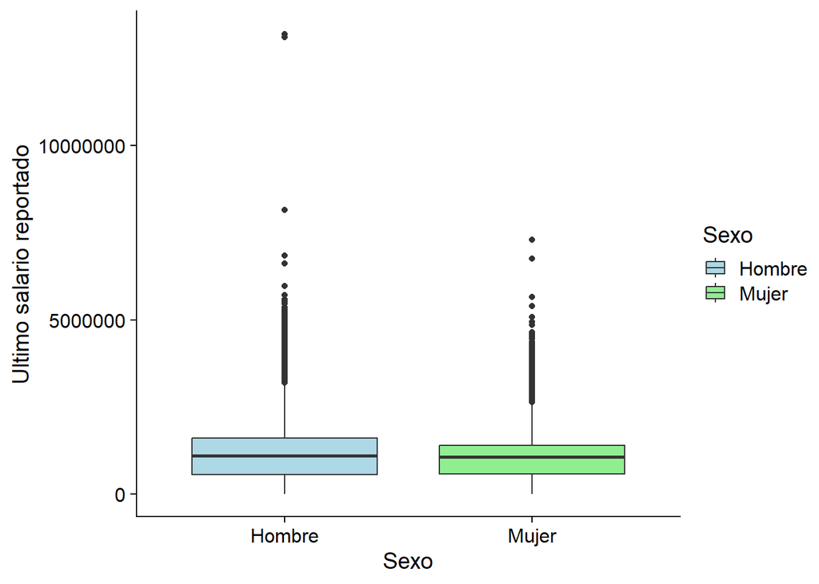